# HIV testing uptake among women in South Africa

Author

Dickman Pangaume Gareta

Published

April 24, 2024

## Introduction

HIV is a public health concern worldwide and efforts are underway to eliminate the virus by 2030. However, knowing one’s HIV status is crucial as it provides an entry point into HIV care, treatment and lifelong support. This is especially important in regions with the highest burden of HIV such as the Sub-Saharan Africa. There is documented evidence that HIV incidence is high among women especially those in the older age groups. Therefore, understanding HIV status among women is key in preventing the acquisition of the disease or linking to HIV care and treatment.

The objective of the project is to evaluate the uptake of HIV testing by social demographic factors among women aged between 15 and 49 years in **South Africa**. The data source for this analysis is the *2016 South Africa Demographic and Health Surveys(DHS)*. More info about the survey can be found [here](https://dhsprogram.com/data/Guide-to-DHS-Statistics/).

# Background characteristics

A total of 8514 women were interviewed during the 2016 Demographic and Health Survey in South Africa. Of these, 7136 (84%) reported to have had HIV test before.

## Education

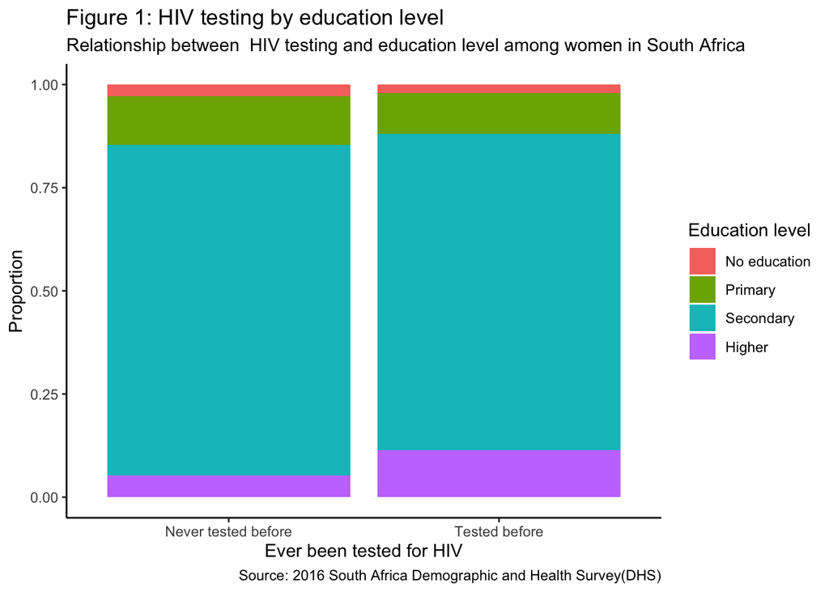

Except the category with no education, the median ages for those who tested for HIV were likely to be greater than the median ages for those who did not test for HIV across different education levels(**Figure 2**).

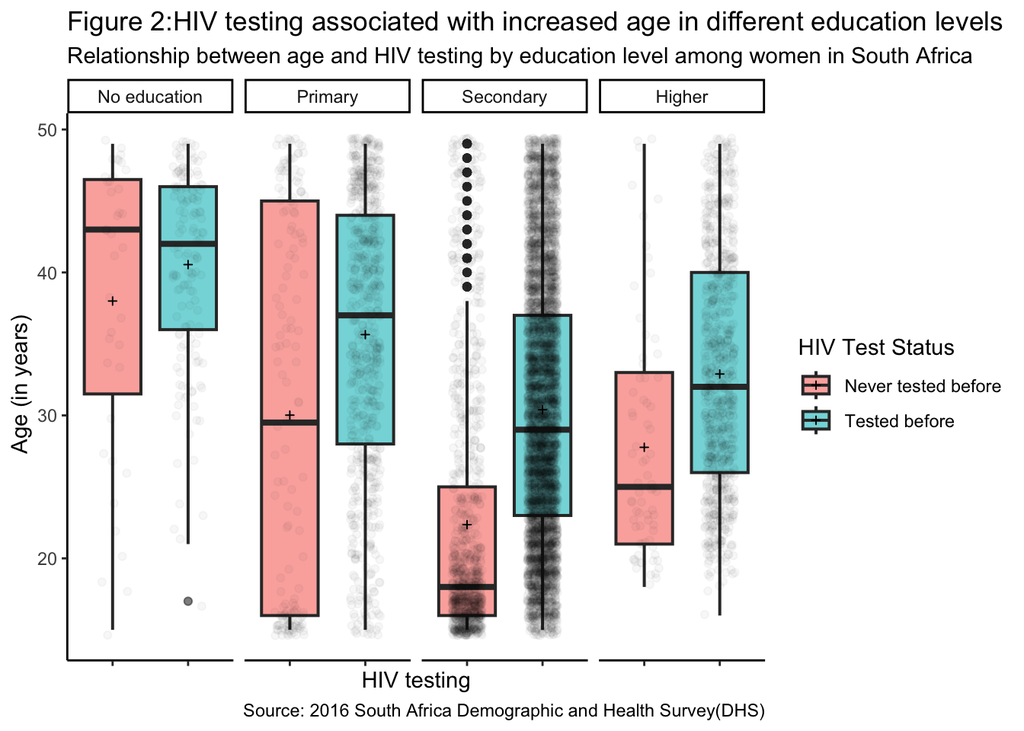

## Residency

A total of 4067(57%) women who reported to have had an HIV test before resided in the rural areas while 738(54%) women who reported not have had an HIV test resided in the rural areas(**Figure 3**).

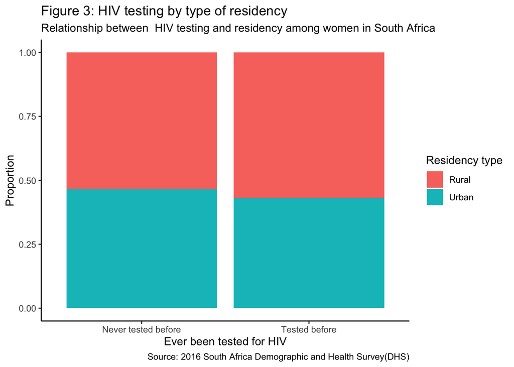

## Social economic status

Of the women who reported to have had an HIV test before, 1572(22%) were from middle-class households. Similarly for those who never had an HIV test before, 314(23%) women were from middle-class households (**Figure 4**).

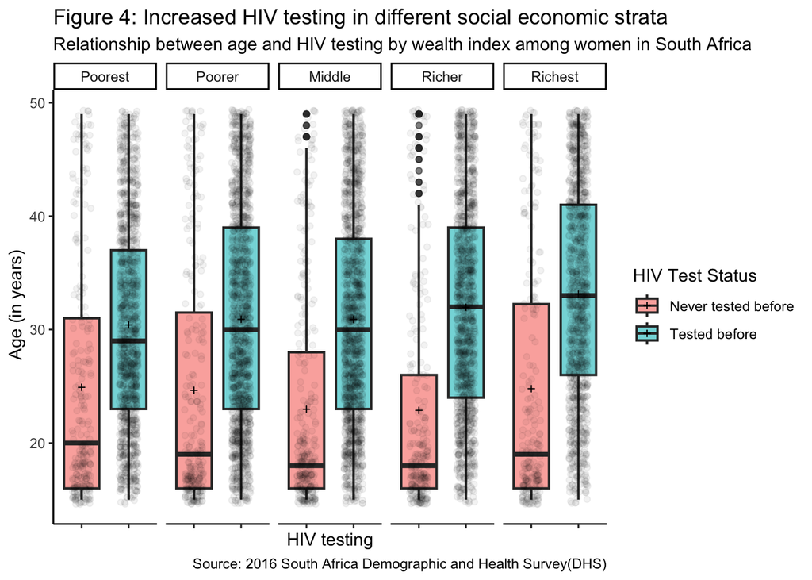

# Conclusion

The recommendation for this project is to encourage interventions aimed at increasing levels of education among women.

# Reference

- [The DHS Program: Demographic and Health Surveys](https://dhsprogram.com/)